[figure not shown]

## Curso: Estadística Para el Análisis Político II Semestre 2017-II

### Prof. José Manuel Magallanes, PhD

## **Análisis Multivariado**

## Técnicas Descriptivas y Exploratorias Multivariadas (Parte I)

En este curso trabajaremos técnicas multivariadas. Lo complejo es justamente la cantidad de variables que intervienen y que requieren muchas veces mucho tratamiento. La mayoría de programas estadísticos (SPSS, STATA, R, etc.) tiene diversas funciones que ayudan a alistar los datos necesarios cuando se tienen muchas variables involucradas. **Esto no era así cuando sólo se trabajaban con dos variables**. **R** es muy versatil para preparar los datos para el análisis multivariado. Usted puede utilizar otro software, como **EXCEL**, para alistarlos, pero si la cantidad de datos es numerosa, pronto encontrará que son muy limitados.

## AGRUPANDO LAS UNIDADES DE ESTUDIO

En general, las tablas de datos se estructuran como una colección de filas (casos o unidades de estudio) y columnas (variables). En este caso, nos interesa agrupar las unidades de estudio (filas). Para este caso, utilizaremos la data creada por el *PNUD*, el Indice de Densidad del Estado. Este índice es producto de combinar otras variables.

La data original del IDE-PNUD está en Excel, lo cual no sería mayor problema, sino fuera por que las *hojas* tienen varios elementos innecesarios para nuestro análisis. Esta data necesita ser tratada para dejarla lista para el análisis multivariado. Este proceso está descrito más abajo, siga este link para revisarlo.

La data preparada para ser analizada podemos encontrarla en el archivo IDE_limpio.xlsx, descarguelo usando este [link](https://github.com/PoliticayGobiernoPUCP/EstadisticaPoliticaGobiernoII/raw/master/sesiones/data/IDE_limpio.xlsx) y guárdelo en la carpeta *data*. Desde ahí comience:

```r
library(openxlsx)
folder='data'
fileName='IDE_limpio.xlsx'
fileToRead=file.path(folder,fileName)
provinciasNew=read.xlsx(fileToRead)
```

La idea es super simple, queremos, en este caso, saber qué provincias son lo sufientemente **similares entre sí** para decidir que formen un grupo homogeneo o conglomerado. Lo atractivo, en este caso, es que las múultiples variables que se tienen permiten darle un **perfil** particular a cada provincia, lo que permite *acercarlas* o *alejarlas* basandonos justamente en tal similitud. podemos usar muchas características de las provincias (esta es una técnica multivariada) para agruparlas.

Veremos aquí una técnica de conglomeración conocidad como la **jerárquica**, limitaremos la aplicación a que multiples variables numéricas.

Veamos que data tenemos, y de qué tipo son:

```r
str(provinciasNew)
```

```
## 'data.frame':    195 obs. of  11 variables:
##  $ regionUbigeo       : chr  "010000" "010000" "010000" "010000" ...
##  $ provinciaUbigeo    : chr  "010200" "010300" "010400" "010500" ...
##  $ regionNombre       : chr  "AMAZONAS" "AMAZONAS" "AMAZONAS" "AMAZONAS" ...
##  $ provinciaNombre    : chr  "Bagua" "Bongará" "Condorcanqui" "Luya" ...
##  $ pob2012            : num  77438 32317 51802 52185 30236 ...
##  $ ide2012            : num  0.662 0.632 0.46 0.605 0.631 ...
##  $ identificacion2012 : num  94.6 97.5 86.2 96.2 97.3 ...
##  $ medicos2012        : num  14.61 9.01 8.56 12.42 14.88 ...
##  $ escolaridad2012    : num  79.8 76.4 52.2 74.7 79.4 ...
##  $ AguaDesague2012    : num  64.5 54.8 37.7 43.3 46.5 ...
##  $ electrificacion2012: num  67.9 72.2 39.5 67.4 67.5 ...
```

Las variables que nos interesan son:

- Población con acta nacimiento o DNI, es un **porcentaje**.
- Médicos por cada 10,000 habitantes, es una **razón**.
- Tasa asistencia a Secundaria (Pob. 12 a 16 años), es un **porcentaje**.
- Viviendas con agua y desague, es un **porcentaje**.
- Viviendas electrificadas, es un **porcentaje**.

Hagamos el subconjunto de variables que necesitemos (de la columna 7 a la 11):

```r
prov_sub=provinciasNew[c(7:11)]
# vemos:
head(prov_sub)
```

```
##   identificacion2012 medicos2012 escolaridad2012 AguaDesague2012
## 1           94.60787   14.609121        79.79018        64.47904
## 2           97.46807    9.010207        76.42404        54.83408
## 3           86.23196    8.556959        52.21494        37.71451
## 4           96.19272   12.418003        74.72597        43.34842
## 5           97.34310   14.878682        79.42439        46.50182
## 6           95.17449   10.110167        77.16833        52.51951
##   electrificacion2012
## 1            67.91462
## 2            72.16926
## 3            39.48908
## 4            67.39611
## 5            67.54610
## 6            63.11765
```

Estas variables son las que necesitan la función para llevar a cabo la técnica, pero hay que hacer algunos ajustes.

1. El subconjunto de la data no tiene como identificar a que caso corresponde cada fila. Aquí podemos usar el *ubigeo* o el *nombre* tal que reemplace los números que figuran a la izquierda de la data. El único requisito es que estos valores sean **únicos**. El ubigeo lo es, pero debemos verificar si el nombre de la provincia lo es:

```r
numFilas=nrow(prov_sub)
sinRepetir=length(unique(provinciasNew$provinciaNombre))
numFilas==sinRepetir # si es TRUE, no hay repetidos
```

```
## [1] TRUE
```

Como no hay nombres repetidos:

```r
row.names(prov_sub)=provinciasNew$provinciaNombre
# ver
head(prov_sub)
```

```
##                      identificacion2012 medicos2012 escolaridad2012
## Bagua                          94.60787   14.609121        79.79018
## Bongará                        97.46807    9.010207        76.42404
## Condorcanqui                   86.23196    8.556959        52.21494
## Luya                           96.19272   12.418003        74.72597
## Rodríguez de Mendoza           97.34310   14.878682        79.42439
## Utcubamba                      95.17449   10.110167        77.16833
##                      AguaDesague2012 electrificacion2012
## Bagua                       64.47904            67.91462
## Bongará                     54.83408            72.16926
## Condorcanqui                37.71451            39.48908
## Luya                        43.34842            67.39611
## Rodríguez de Mendoza        46.50182            67.54610
## Utcubamba                   52.51951            63.11765
```

Ya no están los numeros; y ya tenemos asegurado que los nombres se mantengan durante el análisis.

2. Las variables vienen con unidades de medición diferentes. Para que la técnica de comglomerados funcione adecuadamente, debemos llevar las variables a valores independientes de la unidad de medida:

```r
prov_sub.scaled<- scale(prov_sub)
# resultado
head(prov_sub.scaled)
```

```
##                      identificacion2012 medicos2012 escolaridad2012
## Bagua                       -1.09436397  0.36776299     -0.05610104
## Bongará                      0.06856468 -0.39755431     -0.35513210
## Condorcanqui                -4.49992185 -0.45950881     -2.50574699
## Luya                        -0.44997860  0.06825845     -0.50598013
## Rodríguez de Mendoza         0.01775379  0.40460944     -0.08859598
## Utcubamba                   -0.86397982 -0.24720043     -0.28901303
##                      AguaDesague2012 electrificacion2012
## Bagua                     0.39995304        -0.267919475
## Bongará                  -0.06962008         0.003631957
## Condorcanqui             -0.90310156        -2.082170112
## Luya                     -0.62880972        -0.301012951
## Rodríguez de Mendoza     -0.47528375        -0.291439587
## Utcubamba                -0.18230687        -0.574083951
```

Aquí tenemos puntuaciones Z, para todas la columnas.

3. El paso que sigue es clave. Aquí debemos generar información sobre las similitudes o ‘distancias’ entre las filas basándonos en las columnas:

```r
prov_sub_d <- dist(prov_sub.scaled)
```

4. En *prov_sub_d* están las distancias; lo cual utilizamo en la función aglomeradora.

```r
prov_sub_clusters=hclust(prov_sub_d)
```

Los resultados se exploran visualmente mediante el **dendograma**:

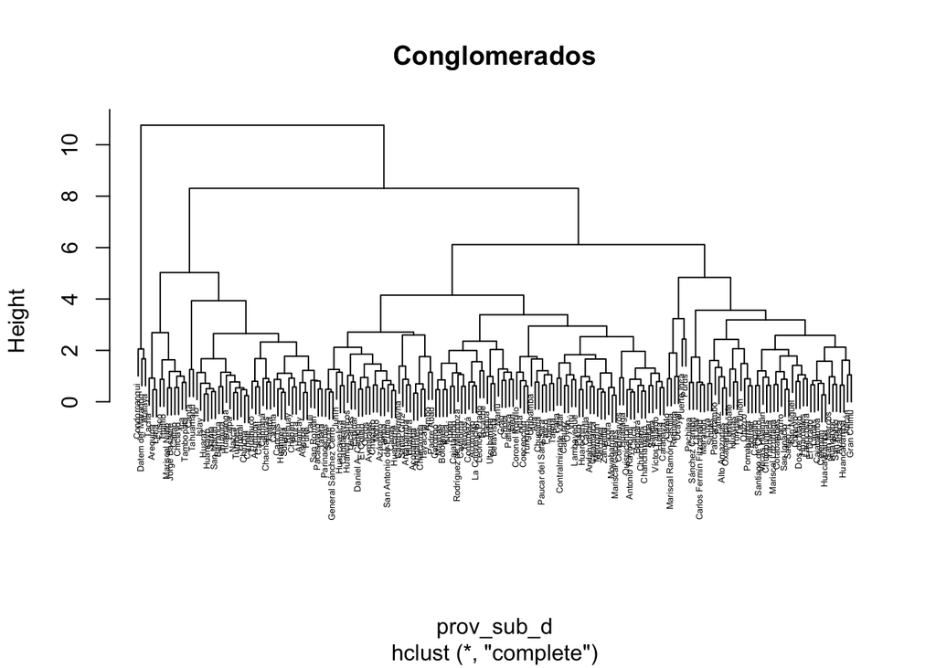

```r
plot(prov_sub_clusters,main='Conglomerados',cex=0.4)
```

Como se ve arriba, cada provincia comenzó aislada en la parte inferior, y luego se van conglomerando.

La técnica muestra el proceso de conglomeración. Por lo general, uno revisa el dendograma y decide a partir de él cuantos conglomerados usar, a partir de esta gráfica.

Si uno decidiése por cuatro conglomerados, tendría que calcularse así:

```r
grupo <- cutree(prov_sub_clusters, k = 4)
```

Para ver quiénes están en el conglomerado, por ejemplo, ‘4’, sería así:

```r
row.names(prov_sub)[grupo == 4]
```

```
##  [1] "Chachapoyas"    "Huaraz"         "Asunción"       "Casma"
##  [5] "Huarmey"        "Recuay"         "Santa"          "Abancay"
##  [9] "Arequipa"       "Camaná"         "Caravelí"       "Islay"
## [13] "Huamanga"       "Callao"         "Cusco"          "Canchis"
## [17] "Huánuco"        "Ica"            "Chincha"        "Nazca"
## [21] "Palpa"          "Huancayo"       "Yauli"          "Trujillo"
## [25] "Ascope"         "Chepén"         "Pacasmayo"      "Chiclayo"
## [29] "Lima"           "Barranca"       "Canta"          "Cañete"
## [33] "Huaral"         "Huaura"         "Tambopata"      "Tahuamanú"
## [37] "Mariscal Nieto" "Ilo"            "Piura"          "Sullana"
## [41] "Talara"         "Puno"           "San Román"      "San Martín"
## [45] "Tacna"          "Jorge Basadre"  "Tarata"         "Tumbes"
```

Este es un data frame con los grupos asignados a cada provincia:

```r
asignaciones=as.data.frame(grupo) # convierto a data frame
# que tengo:
head(asignaciones)
```

```
##                      grupo
## Bagua                    1
## Bongará                  1
## Condorcanqui             2
## Luya                     3
## Rodríguez de Mendoza     1
## Utcubamba                1
```

```r
asignaciones$provincia=row.names(asignaciones) # paso los nombres a columna
# que tengo:
head(asignaciones)
```

```
##                      grupo            provincia
## Bagua                    1                Bagua
## Bongará                  1              Bongará
## Condorcanqui             2         Condorcanqui
## Luya                     3                 Luya
## Rodríguez de Mendoza     1 Rodríguez de Mendoza
## Utcubamba                1            Utcubamba
```

Reseteo los nombres de fila:

```r
row.names(asignaciones)=NULL
# esto queda así
head(asignaciones)
```

```
##   grupo            provincia
## 1     1                Bagua
## 2     1              Bongará
## 3     2         Condorcanqui
## 4     3                 Luya
## 5     1 Rodríguez de Mendoza
## 6     1            Utcubamba
```

**IMPORTANTE**: Si calculásemos clusters con data de otro año, podríamos comparar si una provincia ha mejorado o decaído de uno a otro a año.

Nótese que el número asignada a cada conglomerado no representa ningun orden; es decir, estar en el cluster 2 puede ser mejor que estar en el 1. Para evitar ello, debemos juntar la data qué informa sobre el cluster y la data original:

```r
# recuperando los datos de provincia en una copia.
# asi evito alterar prov_sub en caso la necesite intacta luego.
copia_prov_sub=prov_sub
copia_prov_sub$provincia=row.names(copia_prov_sub)
```

Juntemos la data:

```r
# Añadiendo la información de clusters a esta data:
copia_prov_sub=merge(copia_prov_sub,asignaciones)
row.names(copia_prov_sub)=NULL # reseteando nombre de fila
str(copia_prov_sub)
```

```
## 'data.frame':    195 obs. of  7 variables:
##  $ provincia          : chr  "Abancay" "Acobamba" "Acomayo" "Aija" ...
##  $ identificacion2012 : num  97.9 98.8 97.2 98.2 94 ...
##  $ medicos2012        : num  16.93 2.63 10.45 8.59 10.81 ...
##  $ escolaridad2012    : num  93.7 77.5 83.1 89.5 61.7 ...
##  $ AguaDesague2012    : num  63 31.2 48.2 47.8 44.5 ...
##  $ electrificacion2012: num  90.5 76.7 70.6 79.1 66 ...
##  $ grupo              : int  4 1 1 1 3 1 1 1 1 1 ...
```

Sabiendo que grupo está en la data, pedimos los valores medios:

```r
aggregate(cbind(identificacion2012,medicos2012,escolaridad2012,AguaDesague2012,
                electrificacion2012) ~ grupo, data=copia_prov_sub,FUN=mean)
```

```
##   grupo identificacion2012 medicos2012 escolaridad2012 AguaDesague2012
## 1     1           97.67460    8.830320        83.42065        50.31381
## 2     2           84.16321    5.943809        50.57131        27.67829
## 3     3           95.93970    8.996768        67.35797        46.03336
## 4     4           98.83828   21.380165        90.35708        80.44943
##   electrificacion2012
## 1            73.78446
## 2            46.65043
## 3            54.98529
## 4            88.66154
```

Como se nota, usando la media podríamos renumerar los clustes con valores más informativos, es decir, recodificar esa columna para que represente orden ascendente o descendente (y no en desorden cómo está ahi: peor es el 2, de ahi 3, de ahi 1 y el mejor el 4).

El corte en 4 grupos se puede ver así:

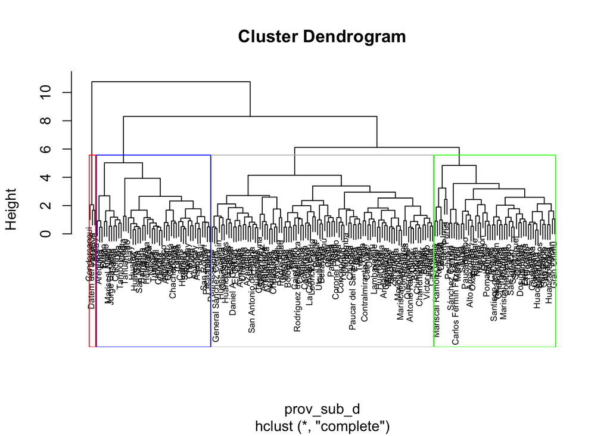

```r
plot(prov_sub_clusters, cex = 0.6)
rect.hclust(prov_sub_clusters, k = 4, border = c('red','blue','gray','green'))
```

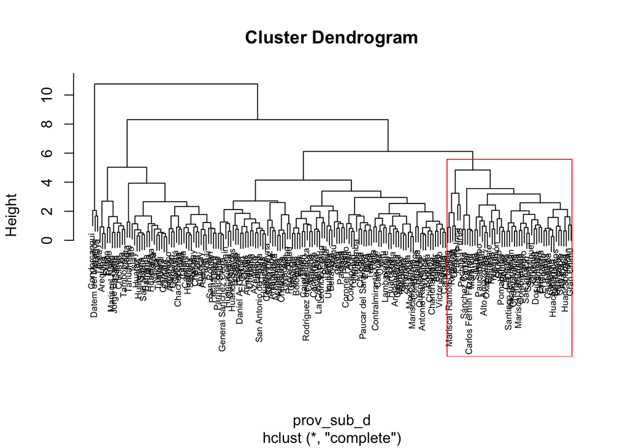

```r
plot(prov_sub_clusters, cex = 0.6)
rect.hclust(prov_sub_clusters, k = 4, border = 'red',which = 4)
```

El dendograma nos muestra el proceso de aglomeración, pero nosotros debemos decidir con cuantos clusters quedarnos.

Lo interesante es que no hay una manera certera de decidir cuántos clusters debemos elegir. De hecho hay diversos indices creados para *sugerir* cuántos. Estos indices podemos verlos de esta manera:

```r
library(NbClust)

#usar aqui las variables normalizadas: prov_sub.scaled
nb <- NbClust(prov_sub.scaled, method = "complete") # 'dist' usa este método por defecto
```

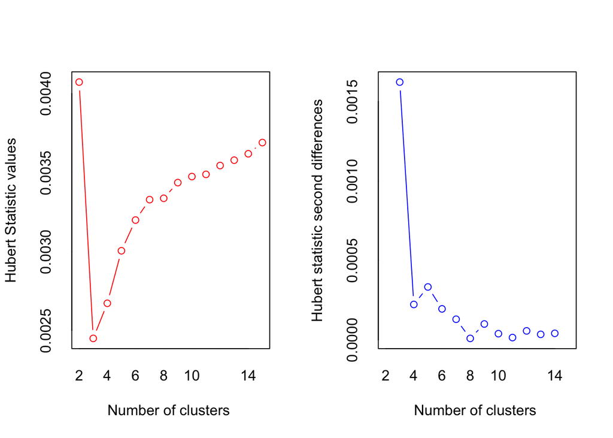

```
## *** : The Hubert index is a graphical method of determining the number of clusters.
##                 In the plot of Hubert index, we seek a significant knee that corresponds to a
##                 significant increase of the value of the measure i.e the significant peak in Hubert
##                 index second differences plot.
##
```

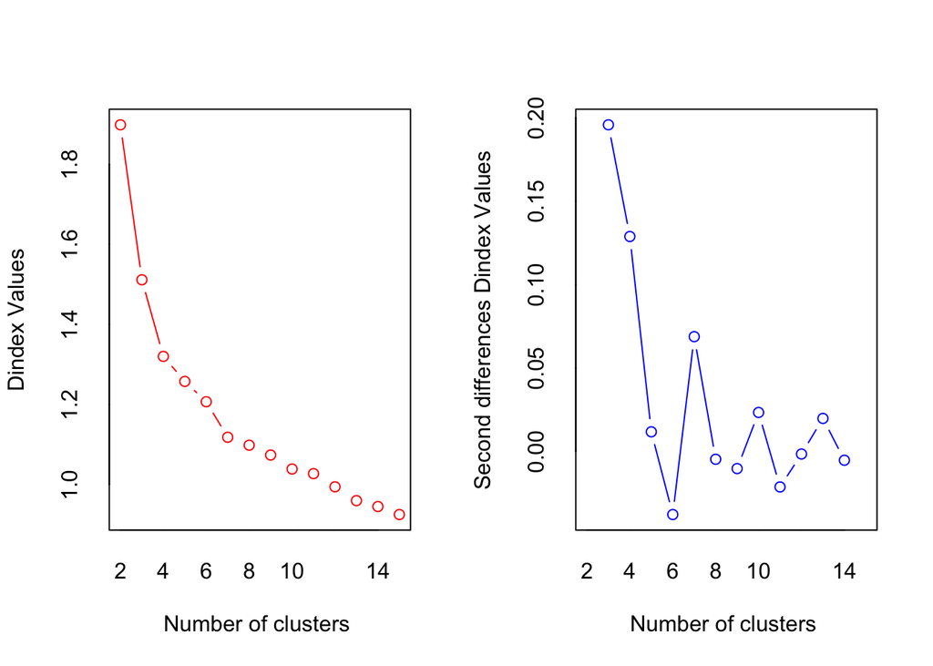

```
## *** : The D index is a graphical method of determining the number of clusters.
##                 In the plot of D index, we seek a significant knee (the significant peak in Dindex
##                 second differences plot) that corresponds to a significant increase of the value of
##                 the measure.
##
## * Among all indices:
## * 6 proposed 2 as the best number of clusters
## * 9 proposed 3 as the best number of clusters
## * 5 proposed 4 as the best number of clusters
## * 2 proposed 5 as the best number of clusters
## * 1 proposed 13 as the best number of clusters
## * 1 proposed 15 as the best number of clusters
##
##                    ***** Conclusion *****
##
## * According to the majority rule, the best number of clusters is  3
##
##
```

Del reporte anterior, se ve que la sugerencia depende de la regla de la mayoria: usar TRES clusters. El resultado anterior se puede plotear así:

```r
library(factoextra) # toma su tiempo
```

```
## Among all indices:
## ===================
## * 2 proposed  0 as the best number of clusters
## * 6 proposed  2 as the best number of clusters
## * 9 proposed  3 as the best number of clusters
## * 5 proposed  4 as the best number of clusters
## * 2 proposed  5 as the best number of clusters
## * 1 proposed  13 as the best number of clusters
## * 1 proposed  15 as the best number of clusters
##
## Conclusion
## =========================
## * According to the majority rule, the best number of clusters is  3 .
```

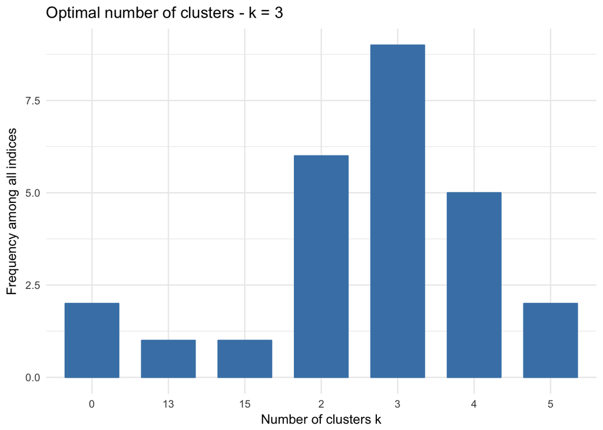

```r
fviz_nbclust(nb) + theme_minimal()
```

El paquete *factoextra* tiene su propia función para calcular conglomerados (‘eclust’).

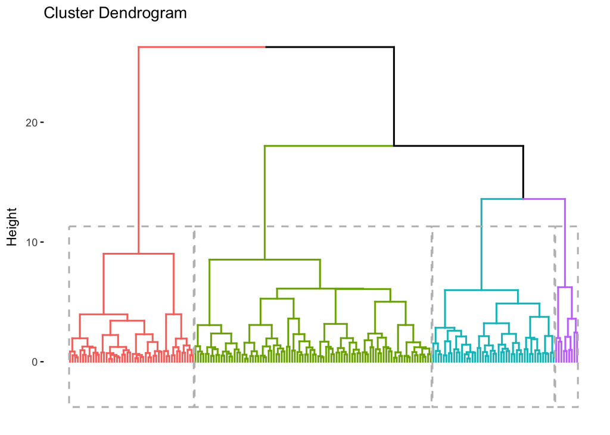

```r
# resultado de factoExtra (FE)
prov_sub_clusters_FE <- eclust(prov_sub.scaled, FUNcluster ="hclust", k = 4,
                method = "complete", graph = FALSE)
fviz_dend(prov_sub_clusters_FE, rect = TRUE, show_labels = FALSE)
```

Este resultado también guarda los clusters:

```r
head(as.data.frame(prov_sub_clusters_FE$cluster))
```

```
##                      prov_sub_clusters_FE$cluster
## Bagua                                           1
## Bongará                                         1
## Condorcanqui                                    2
## Luya                                            3
## Rodríguez de Mendoza                            1
## Utcubamba                                       1
```

Nótese que los resultados de esta función han salido iguales a los hallados con el **hclust** básico.

Lo importante de este paquete es que nos permite validar qué tan buena ha sido nuestra aglomeración. Para ello calcula las **siluetas**:

```
##   cluster size ave.sil.width
## 1       1   91          0.21
## 2       2    9          0.27
## 3       3   47          0.29
## 4       4   48          0.41
```

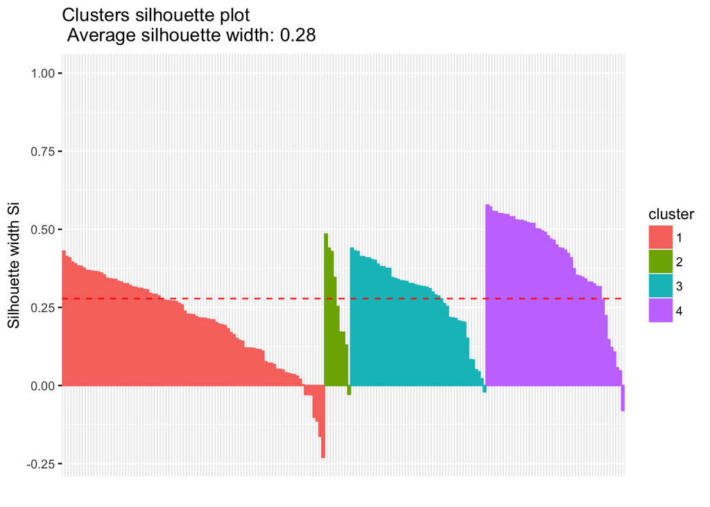

```r
fviz_silhouette(prov_sub_clusters_FE)
```

Un valor cercano a **uno** indica que el valor está bien aglomerado, si está cercano a cero indica que esta entre dos conglomerados, y si es negativo, que está en un cluster erróneo (al algoritmo acabó y no pudo ubicarlo en el grupo adecuado).

El objeto *prov_sub_clusters_FE* guarda esta información de silueta. Para acceder a ella tenemos:

```r
siluetas <-prov_sub_clusters_FE$silinfo$widths
```

Para ver los que están mal agrupados tenemos:

```r
siluetas[siluetas$sil_width<0,]
```

```
##                      cluster neighbor   sil_width
## Bellavista                 1        3 -0.02875950
## Manú                       1        3 -0.02921478
## Paucar del Sara Sara       1        4 -0.02948571
## Huanta                     1        3 -0.10171815
## Utcubamba                  1        3 -0.11359367
## Huánuco                    1        4 -0.16274596
## Tahuamanú                  1        4 -0.23016849
## Requena                    2        3 -0.02818924
## Chota                      3        1 -0.02005738
## Recuay                     4        1 -0.08004698
```

Ya sabemos que si a loss resultados que acabamos de ver les aplicamos la función *as.data.frame* podremos manipularlos como cualquier tabla de datos.

### NOTA IMPORTANTE:

Cuando utilizamos la función **scale** para normalizar las variables usamos los valores por defecto de esa función, es decir, la *media* y la *desviación típica*. Podríamos usar las medianas y la desviaciónes de la mediana en vez de ellas:

```r
medians = apply(prov_sub,2,median)
mads = apply(prov_sub,2,mad)
prov_sub.scaled2 = scale(prov_sub,center=medians,scale=mads)
```

Habrán cambios cualitativos si usamos estos nuevos valores?

## Preparación de la data multivariada

La data original es esta en el archivo “idePeru.xlsx” que lo puede descargar de [aquí](https://github.com/PoliticayGobiernoPUCP/EstadisticaPoliticaGobiernoII/raw/master/sesiones/data/idhPeru.xlsx).

Descargue la data y guardela en la carpeta *data*. Desde ahí comience a trabajar:

```r
library(openxlsx)
folder='data'
fileName='idePeru.xlsx'
fileToRead=file.path(folder,fileName)
cualHoja=1
datos<- read.xlsx(fileToRead, cualHoja)
head(datos,10)
```

```
##    ÍNDICE.DE.DENSIDAD.DEL.ESTADO.2012:.DEPARTAMENTAL.Y.PROVINCIAL
## 1                                                     Ubigeo 2010
## 2                                                            <NA>
## 3                                                            <NA>
## 4                                                            <NA>
## 5                                                          000000
## 6                                                          010000
## 7                                                          010100
## 8                                                          010200
## 9                                                          010300
## 10                                                         010400
##              X2           X3             X4      X5
## 1  DEPARTAMENTO         <NA>           <NA>    <NA>
## 2          <NA>         <NA> Población 2012    <NA>
## 3          <NA>    Provincia           <NA>    <NA>
```

[output cut: 62 more lines]

Esta data tiene malos títulos:

```r
names(datos)
```

```
##  [1] "ÍNDICE.DE.DENSIDAD.DEL.ESTADO.2012:.DEPARTAMENTAL.Y.PROVINCIAL"
##  [2] "X2"
##  [3] "X3"
##  [4] "X4"
##  [5] "X5"
##  [6] "X6"
##  [7] "X7"
##  [8] "X8"
##  [9] "X9"
## [10] "X10"
## [11] "X11"
## [12] "X12"
## [13] "X13"
## [14] "X14"
## [15] "X15"
## [16] "X16"
## [17] "X17"
```

**Openxlsx** es muy eficiente, pues inclusive omite columnas vacías. Sin embargo, vemos que la data no inicia donde debe, los titulos no corresponden a las columnas; y, aunque las Provincias figuran en cada fila, los Departamentos no están en las filas, sino como titulos para las provincias (y por aún no hay distritos, aunque la hoja muestra ese nombre). Arreglemos esto.

```r
filaInicial=4 # Desde aquí comienzas a leer. Asegúrese que no pierde titulos.
datos=read.xlsx(fileToRead,
                sheet = 1,
                startRow = filaInicial,
                skipEmptyRows = TRUE, skipEmptyCols = TRUE)

# ver:
head(datos)
```

```
##       X1       X2          X3 Población.2012      X5
## 1   <NA>     <NA>   Provincia           <NA>    <NA>
## 2   <NA>     <NA>    Distrito     habitantes ranking
## 3 000000 PERÚ  a/        <NA>       30135875       -
## 4 010000 AMAZONAS        <NA>         417508      20
## 5 010100     <NA> Chachapoyas          54783     113
## 6 010200     <NA>       Bagua          77438      79
##   Índice.de.Densidad.del.Estado      X7
## 1                          <NA>    <NA>
## 2                           IDE ranking
## 3           0.76662632867783975       -
## 4           0.62795269269252496      20
## 5           0.77369947765747837      26
## 6           0.66228046503747584      82
##   Población.con.acta.nacimiento.o.DNI      X9
```

[output cut: 27 more lines]

Es importante que la **filaInicial** permita que la data que recuperes te de los titulo, no como el caso anterior, veamos que tenemos antes:

```r
names(datos)
```

```
##  [1] "X1"
##  [2] "X2"
##  [3] "X3"
##  [4] "Población.2012"
##  [5] "X5"
##  [6] "Índice.de.Densidad.del.Estado"
##  [7] "X7"
##  [8] "Población.con.acta.nacimiento.o.DNI"
##  [9] "X9"
## [10] "Médicos.por.cada.10,000.habitantes"
## [11] "X11"
## [12] "Tasa.asistencia.a.Secundaria.(Pob..12.a.16.años)"
## [13] "X13"
## [14] "Viviendas.con.agua.y.desague"
## [15] "X15"
## [16] "Viviendas.electrificadas"
## [17] "X17"
```

Este es buen comienzo. Ahora veamos si las últimas filas tienen data, u elementos innecesarios:

```r
tail(datos,10)
```

```
##                                                                                                                                                                                                                     X1
## 217                                                                                                                                                                                                             240300
## 218                                                                                                                                                                                                             250000
## 219                                                                                                                                                                                                             250100
## 220                                                                                                                                                                                                             250200
## 221                                                                                                                                                                                                             250300
## 222                                                                                                                                                                                                             250400
## 223 a/ Incluye las cifras estimadas del distrito de Carmen Alto en la provincia de Huamanga, departamento de Ayacucho, donde. Autoridades locales no permitieron la ejecución del Censo de Población y Vivienda 2007.
## 224                                                                                                 1/ Incluye a la población ubicada en área temporal por límites de fronteras de los distritos de Pangoa y Mazamari.
## 225                                                                                                                                       Fuente: INEI. Censo de Población y Vivienda 2007. ENAHO 2012 y ENAPRES 2012.
## 226                                                                                                                                                                                            Elaboración: PNUD-Perú.
##          X2               X3 Población.2012   X5
## 217    <NA>        Zarumilla          49499  126
## 218 UCAYALI             <NA>         477616   18
## 219    <NA> Coronel Portillo         366040   11
```

[output cut: 51 more lines]

La data acaba en la fila 222, con la provincia de **Purus**. Eliminemos filas innecesarias:

```r
# no queremos de la fila 223 a la 226 (nota la ',')
datos=datos[-c(223:226),] # para eliminar 4 ultimas filas use también: datos=head(datos,-4)
```

El encabezado también puede tener filas innecesarias:

```r
head(datos)
```

```
##       X1       X2          X3 Población.2012      X5
## 1   <NA>     <NA>   Provincia           <NA>    <NA>
## 2   <NA>     <NA>    Distrito     habitantes ranking
## 3 000000 PERÚ  a/        <NA>       30135875       -
## 4 010000 AMAZONAS        <NA>         417508      20
## 5 010100     <NA> Chachapoyas          54783     113
## 6 010200     <NA>       Bagua          77438      79
##   Índice.de.Densidad.del.Estado      X7
## 1                          <NA>    <NA>
## 2                           IDE ranking
## 3           0.76662632867783975       -
## 4           0.62795269269252496      20
## 5           0.77369947765747837      26
## 6           0.66228046503747584      82
##   Población.con.acta.nacimiento.o.DNI      X9
```

[output cut: 27 more lines]

Piensa en la esquina superior izquierda de un **cuadrado** (tabla) cuando quieras eliminar filas: éste puede comenzar en el ubigeo de AMAZONAS. De ahí que las filas 1 al 3 nos innecesarias:

```r
datos=datos[-c(1:3),] # para eliminar 3 primeras filas use también: datos=tail(datos,-3)

# asi va quedando:
head(datos)
```

```
##       X1       X2           X3 Población.2012  X5
## 4 010000 AMAZONAS         <NA>         417508  20
## 5 010100     <NA>  Chachapoyas          54783 113
## 6 010200     <NA>        Bagua          77438  79
## 7 010300     <NA>      Bongará          32317 145
## 8 010400     <NA> Condorcanqui          51802 119
## 9 010500     <NA>         Luya          52185 117
##   Índice.de.Densidad.del.Estado  X7 Población.con.acta.nacimiento.o.DNI
## 4           0.62795269269252496  20                  94.942033052925879
## 5           0.77369947765747837  26                  98.617881202736541
## 6           0.66228046503747584  82                  94.607868232246133
## 7           0.63182491983336697 103                  97.468069451399515
## 8           0.45982417359739747 191                  86.231962490583811
## 9           0.60471977563772472 126                  96.192721992265234
##    X9 Médicos.por.cada.10,000.habitantes X11
```

[output cut: 20 more lines]

Piensa estratégucamente ahora. Los ubigeos tienen mezclados los de Departamento o Región con los de provincia en la misma columna (la X1). Pero en la columna de al lado (X2) hay celdas vacias salvo cuando aparece el nombre de la region. Creemos entonces dos subsets (subtabla de *datos*), uno para región y otro para distrito.

Primero lo de regiones:

```r
queColumnas=c(1,2)
regiones=datos[,queColumnas] # subtabla 'regiones' (subset de 'data') / note donde está la coma','
# asi va
head(regiones,10)
```

```
##        X1       X2
## 4  010000 AMAZONAS
## 5  010100     <NA>
## 6  010200     <NA>
## 7  010300     <NA>
## 8  010400     <NA>
## 9  010500     <NA>
## 10 010600     <NA>
## 11 010700     <NA>
## 12 020000   ANCASH
## 13 020100     <NA>
```

Vemos que los ubigeos que tiene al lado las celdas vacías (*NA*) son ubigeos de provincias; de ahí que esas filas no las necesitamos. Pidamos a R que *regiones* se quede con las filas (**cases**) que tengan valores completos:

```r
regiones=regiones[complete.cases(regiones),] # note la posición de la coma ','
# así va:
regiones
```

```
##         X1            X2
## 4   010000      AMAZONAS
## 12  020000        ANCASH
## 33  030000      APURÍMAC
## 41  040000      AREQUIPA
## 50  050000      AYACUCHO
## 62  060000     CAJAMARCA
## 77  080000         CUSCO
## 91  090000  HUANCAVELICA
## 99  100000       HUÁNUCO
## 111 110000           ICA
## 117 120000         JUNÍN
## 127 130000   LA LIBERTAD
## 140 140000    LAMBAYEQUE
## 144 150000          LIMA
## 155 160000        LORETO
## 163 170000 MADRE DE DIOS
## 167 180000      MOQUEGUA
## 171 190000         PASCO
## 175 200000         PIURA
## 184 210000          PUNO
## 198 220000    SAN MARTÍN
## 209 230000         TACNA
## 214 240000        TUMBES
## 218 250000       UCAYALI
```

Pues tenemos todos los departamentos del Perú con sus ubigeos. Sólo faltaría darle nombre a sus columnas

```r
nombresNuevos=c('regionUbigeo','regionNombre')
names(regiones)=nombresNuevos

# asi va:
head(regiones)
```

```
##    regionUbigeo regionNombre
## 4        010000     AMAZONAS
## 12       020000       ANCASH
## 33       030000     APURÍMAC
## 41       040000     AREQUIPA
## 50       050000     AYACUCHO
## 62       060000    CAJAMARCA
```

Regresemos a ‘data’:

```r
#veamos:
head(datos)
```

```
##       X1       X2           X3 Población.2012  X5
## 4 010000 AMAZONAS         <NA>         417508  20
## 5 010100     <NA>  Chachapoyas          54783 113
## 6 010200     <NA>        Bagua          77438  79
## 7 010300     <NA>      Bongará          32317 145
## 8 010400     <NA> Condorcanqui          51802 119
## 9 010500     <NA>         Luya          52185 117
##   Índice.de.Densidad.del.Estado  X7 Población.con.acta.nacimiento.o.DNI
## 4           0.62795269269252496  20                  94.942033052925879
## 5           0.77369947765747837  26                  98.617881202736541
## 6           0.66228046503747584  82                  94.607868232246133
## 7           0.63182491983336697 103                  97.468069451399515
## 8           0.45982417359739747 191                  86.231962490583811
## 9           0.60471977563772472 126                  96.192721992265234
##    X9 Médicos.por.cada.10,000.habitantes X11
```

[output cut: 20 more lines]

En *X1* están los ubigeos de las provincias, pero también de los departamentos. En *X2* aparecen los nombres de los departamentos, y en *X3* los nombres de las provincias. Con esta información creemos la subtabla provincias:

- Eliminemos la segunda columna (*X2*) pues no es necesaria:

```r
queColumnas=c(2)
provincias=datos[,-queColumnas] # subtabla 'provincoas' (subset de 'data') / note donde está la coma','

# asi va:
head(provincias,10)
```

```
##        X1                   X3 Población.2012  X5
## 4  010000                 <NA>         417508  20
## 5  010100          Chachapoyas          54783 113
## 6  010200                Bagua          77438  79
## 7  010300              Bongará          32317 145
## 8  010400         Condorcanqui          51802 119
## 9  010500                 Luya          52185 117
## 10 010600 Rodríguez de Mendoza          30236 153
## 11 010700            Utcubamba         118747  51
## 12 020000                 <NA>        1129391  10
## 13 020100               Huaraz         161003  31
##    Índice.de.Densidad.del.Estado  X7 Población.con.acta.nacimiento.o.DNI
## 4            0.62795269269252496  20                  94.942033052925879
## 5            0.77369947765747837  26                  98.617881202736541
## 6            0.66228046503747584  82                  94.607868232246133
```

[output cut: 40 more lines]

Veamos que columnas tenemos:

```r
names(provincias)
```

```
##  [1] "X1"
##  [2] "X3"
##  [3] "Población.2012"
##  [4] "X5"
##  [5] "Índice.de.Densidad.del.Estado"
##  [6] "X7"
##  [7] "Población.con.acta.nacimiento.o.DNI"
##  [8] "X9"
##  [9] "Médicos.por.cada.10,000.habitantes"
## [10] "X11"
## [11] "Tasa.asistencia.a.Secundaria.(Pob..12.a.16.años)"
## [12] "X13"
## [13] "Viviendas.con.agua.y.desague"
## [14] "X15"
## [15] "Viviendas.electrificadas"
## [16] "X17"
```

*X1* y *X3* son necesarias, ahi están los ubigeos de las provincias y sus nombres. Todas las otras que comienzan con X son los rankings, y no los necesitamos. Vemos que sus posiciones como columna van de la 4 a la 16 saltando uno, osea sus posiciones son:

```r
seq(4,16,2)  # seq(inicio, fin, salto)
```

```
## [1]  4  6  8 10 12 14 16
```

Gracias a este comando, podemos eliminar esas columnas

```r
queColumnas=seq(4,16,2)
provincias=provincias[,-queColumnas]

# estas columnas quedan:
names(provincias)
```

```
## [1] "X1"
## [2] "X3"
## [3] "Población.2012"
## [4] "Índice.de.Densidad.del.Estado"
## [5] "Población.con.acta.nacimiento.o.DNI"
## [6] "Médicos.por.cada.10,000.habitantes"
## [7] "Tasa.asistencia.a.Secundaria.(Pob..12.a.16.años)"
## [8] "Viviendas.con.agua.y.desague"
## [9] "Viviendas.electrificadas"
```

Renombremos las dos primeras columnas

```r
names(provincias)[c(1,2)]=c('provinciaUbigeo','provinciaNombre')

# asi va:
head(provincias)
```

```
##   provinciaUbigeo provinciaNombre Población.2012
## 4          010000            <NA>         417508
## 5          010100     Chachapoyas          54783
## 6          010200           Bagua          77438
## 7          010300         Bongará          32317
## 8          010400    Condorcanqui          51802
## 9          010500            Luya          52185
##   Índice.de.Densidad.del.Estado Población.con.acta.nacimiento.o.DNI
## 4           0.62795269269252496                  94.942033052925879
## 5           0.77369947765747837                  98.617881202736541
## 6           0.66228046503747584                  94.607868232246133
## 7           0.63182491983336697                  97.468069451399515
## 8           0.45982417359739747                  86.231962490583811
## 9           0.60471977563772472                  96.192721992265234
##   Médicos.por.cada.10,000.habitantes
```

[output cut: 20 more lines]

Todas las filas de provincias tienen la data completa. Pero esta tabla o cuadrado hay que reducirlo: donde estan los ubigeos de departamento hay una celda vacia, y la data de esas filas son los totales del departamento. De ahí que quedemosnos solo con las filas de provincias (asi se llama la subtabla). Para eliminar las filas (casos) de los departamentos, digamosle nuevamente a R que se quede con la data completa, y como las filas de departamento tienen una celda con *NA*, esa fila se eliminará.

```r
provincias=provincias[complete.cases(provincias),]

# asi va:
head(provincias,10)
```

```
##    provinciaUbigeo      provinciaNombre Población.2012
## 5           010100          Chachapoyas          54783
## 6           010200                Bagua          77438
## 7           010300              Bongará          32317
## 8           010400         Condorcanqui          51802
## 9           010500                 Luya          52185
## 10          010600 Rodríguez de Mendoza          30236
## 11          010700            Utcubamba         118747
## 13          020100               Huaraz         161003
## 14          020200                 Aija           7974
## 15          020300     Antonio Raymondi          16879
##    Índice.de.Densidad.del.Estado Población.con.acta.nacimiento.o.DNI
## 5            0.77369947765747837                  98.617881202736541
## 6            0.66228046503747584                  94.607868232246133
## 7            0.63182491983336697                  97.468069451399515
```

[output cut: 40 more lines]

**ADVERTENCIA**: El comando anterior puede eliminar a una fila con data de provincia si es que alguna de sus celdas tenía un *NA*. Un comando que garantice quedarse con las filas donde una celda esté vacía en alguna columna en particular es:

```r
provincias[complete.cases(provincias$provinciaNombre),]
```

Por un asunto *decorativo*, simplifiquemos los otros nombres de columnas:

```r
names(provincias)
```

```
## [1] "provinciaUbigeo"
## [2] "provinciaNombre"
## [3] "Población.2012"
## [4] "Índice.de.Densidad.del.Estado"
## [5] "Población.con.acta.nacimiento.o.DNI"
## [6] "Médicos.por.cada.10,000.habitantes"
## [7] "Tasa.asistencia.a.Secundaria.(Pob..12.a.16.años)"
## [8] "Viviendas.con.agua.y.desague"
## [9] "Viviendas.electrificadas"
```

De ahí que podemos cambiar:

```r
# estamos cambiando los nombres de la columna 3 hasta la 9
# hay que ingresar los nombres en el orden que se requiere
names(provincias)[c(3:9)]=c('pob2012','ide2012','identificacion2012','medicos2012','escolaridad2012','AguaDesague2012','electrificacion2012')

# asi queda
head(provincias)
```

```
##    provinciaUbigeo      provinciaNombre pob2012             ide2012
## 5           010100          Chachapoyas   54783 0.77369947765747837
## 6           010200                Bagua   77438 0.66228046503747584
## 7           010300              Bongará   32317 0.63182491983336697
## 8           010400         Condorcanqui   51802 0.45982417359739747
## 9           010500                 Luya   52185 0.60471977563772472
## 10          010600 Rodríguez de Mendoza   30236 0.63122642672378437
##    identificacion2012        medicos2012    escolaridad2012
## 5  98.617881202736541 25.450023719049433 91.498562457256497
## 6  94.607868232246133 14.609120874914693 79.790177700938358
## 7  97.468069451399515 9.0102065354508269 76.424036582846838
## 8  86.231962490583811 8.5569592849723382 52.214935311064806
## 9  96.192721992265234 12.418003208422093 74.725966346695259
## 10 97.343101025328792  14.87868246110053 79.424387744349531
##       AguaDesague2012 electrificacion2012
## 5  70.345402142059839  83.971186828270632
## 6  64.479036686809536   67.91461510721939
## 7  54.834081786102814  72.169261203916292
## 8  37.714508854591834  39.489081334171054
## 9  43.348418298915448  67.396109166949586
## 10 46.501816616265728  67.546103874113939
```

La data está casi lista, pero queda verificar que la data a a poder ser tratada de la manera esperada. Por ejemplo, debería ser posible sacar la media aritmetica de la column población (*pob2012*):

```r
mean(provincias$pob2012)
```

```
## [1] NA
```

Si aplicas una función numérica, y sale error, es por que quizas los datos tengan problemas. Aqui es necesario ver la e**str**uctura:

```r
str(provincias)
```

```
## 'data.frame':    195 obs. of  9 variables:
##  $ provinciaUbigeo    : chr  "010100" "010200" "010300" "010400" ...
##  $ provinciaNombre    : chr  "Chachapoyas" "Bagua" "Bongará" "Condorcanqui" ...
##  $ pob2012            : chr  "54783" "77438" "32317" "51802" ...
##  $ ide2012            : chr  "0.77369947765747837" "0.66228046503747584" "0.63182491983336697" "0.45982417359739747" ...
##  $ identificacion2012 : chr  "98.617881202736541" "94.607868232246133" "97.468069451399515" "86.231962490583811" ...
##  $ medicos2012        : chr  "25.450023719049433" "14.609120874914693" "9.0102065354508269" "8.5569592849723382" ...
##  $ escolaridad2012    : chr  "91.498562457256497" "79.790177700938358" "76.424036582846838" "52.214935311064806" ...
##  $ AguaDesague2012    : chr  "70.345402142059839" "64.479036686809536" "54.834081786102814" "37.714508854591834" ...
##  $ electrificacion2012: chr  "83.971186828270632" "67.91461510721939" "72.169261203916292" "39.489081334171054" ...
```

Las funciones numéricas no pueden aplicarse a los textos (‘chr’), y todos los numeros aparecen como texto. La función **as.numeric** debe aplicarse a varias columnas:

```r
# ESTO NO FUNCIONA!!!!!!
as.numeric(provincias[,c(3:9)])
```

Si fuera sólo una columna, el comando anterior hubiera funcionado. Como son varias, hay que decirle a R que aplique esta función **columna por columna**; para eso tenemos **lapply**:

```r
provincias[,c(3:9)]=lapply(provincias[,c(3:9)],as.numeric)
# ahora
str(provincias)
```

```
## 'data.frame':    195 obs. of  9 variables:
##  $ provinciaUbigeo    : chr  "010100" "010200" "010300" "010400" ...
##  $ provinciaNombre    : chr  "Chachapoyas" "Bagua" "Bongará" "Condorcanqui" ...
##  $ pob2012            : num  54783 77438 32317 51802 52185 ...
##  $ ide2012            : num  0.774 0.662 0.632 0.46 0.605 ...
##  $ identificacion2012 : num  98.6 94.6 97.5 86.2 96.2 ...
##  $ medicos2012        : num  25.45 14.61 9.01 8.56 12.42 ...
##  $ escolaridad2012    : num  91.5 79.8 76.4 52.2 74.7 ...
##  $ AguaDesague2012    : num  70.3 64.5 54.8 37.7 43.3 ...
##  $ electrificacion2012: num  84 67.9 72.2 39.5 67.4 ...
```

Ahora si funciona:

```r
mean(provincias$pob2012) # si hay NA, hay que escribir: mean(provincias$pob2012,na.rm=T), para obviarlos
```

```
## [1] 154542.9
```

Veamos la data de nuevo, provincias:

```r
head(provincias)
```

```
##    provinciaUbigeo      provinciaNombre pob2012   ide2012
## 5           010100          Chachapoyas   54783 0.7736995
## 6           010200                Bagua   77438 0.6622805
## 7           010300              Bongará   32317 0.6318249
## 8           010400         Condorcanqui   51802 0.4598242
## 9           010500                 Luya   52185 0.6047198
## 10          010600 Rodríguez de Mendoza   30236 0.6312264
##    identificacion2012 medicos2012 escolaridad2012 AguaDesague2012
## 5            98.61788   25.450024        91.49856        70.34540
## 6            94.60787   14.609121        79.79018        64.47904
## 7            97.46807    9.010207        76.42404        54.83408
## 8            86.23196    8.556959        52.21494        37.71451
## 9            96.19272   12.418003        74.72597        43.34842
## 10           97.34310   14.878682        79.42439        46.50182
##    electrificacion2012
## 5             83.97119
## 6             67.91462
## 7             72.16926
## 8             39.48908
## 9             67.39611
## 10            67.54610
```

… y departamentos (que le hemos llamado regiones):

```r
head(regiones)
```

```
##    regionUbigeo regionNombre
## 4        010000     AMAZONAS
## 12       020000       ANCASH
## 33       030000     APURÍMAC
## 41       040000     AREQUIPA
## 50       050000     AYACUCHO
## 62       060000    CAJAMARCA
```

Como queremos que el departamento aparezca al costado de su región, sabemos que necesitamos juntar de nuevo ambas subtablas. Esto es algo trivial, *si ambas tablas tienen una columna en común*: la columna llave (o *key*).

La key debemos ponerla en la subtabla mayor, es decir la de provincias. Afortunadamente, del ubigeo de provincia podemos crear el ubigeo de departamento, para asi tener la key en ambas.

Esto simplemente significa:

1. Retener los dos primeros digitos del ubigeo de provincia.
2. Añadirle ‘0000’ a la cola de lo que acabamos de retener.

Esto sería así, usando el comando **paste0**:

```r
retenidos=substr(provincias$provinciaUbigeo,1,2)
aLaCola='0000'
# 'paste0' se encarga de pegar/añadir:
provincias$regionUbigeo=paste0(retenidos,aLaCola)
```

Como ya tenemos una key, podemos juntar ambas subtablas usando el comando **merge**:

```r
provinciasNew=merge(provincias,regiones,
                    by.x = 'regionUbigeo',
                    by.y='regionUbigeo',
                    all.x = TRUE) # Esto detecta si alguna provincia no encontró Region.
```

*provinciasNew* es la tabla que integra las anteriores. El comando **merge** lo he escrito de manera super explicita, pues no necesitaba indicar los keys en los argumentos *by.x* ni *by.y*: cuando las keys de ambas subtablas llevan el mismo nombre no se necesita. Osea el comando anterior pudo ser:

```r
provinciasNew=merge(provincias,regiones,all.x = TRUE) # all.X si lo dejo
```

La data está casi lista:

```r
head(provinciasNew)
```

```
##   regionUbigeo provinciaUbigeo      provinciaNombre pob2012   ide2012
## 1       010000          010200                Bagua   77438 0.6622805
## 2       010000          010300              Bongará   32317 0.6318249
## 3       010000          010400         Condorcanqui   51802 0.4598242
## 4       010000          010500                 Luya   52185 0.6047198
## 5       010000          010600 Rodríguez de Mendoza   30236 0.6312264
## 6       010000          010700            Utcubamba  118747 0.6096605
##   identificacion2012 medicos2012 escolaridad2012 AguaDesague2012
## 1           94.60787   14.609121        79.79018        64.47904
## 2           97.46807    9.010207        76.42404        54.83408
## 3           86.23196    8.556959        52.21494        37.71451
## 4           96.19272   12.418003        74.72597        43.34842
## 5           97.34310   14.878682        79.42439        46.50182
## 6           95.17449   10.110167        77.16833        52.51951
##   electrificacion2012 regionNombre
## 1            67.91462     AMAZONAS
## 2            72.16926     AMAZONAS
## 3            39.48908     AMAZONAS
## 4            67.39611     AMAZONAS
## 5            67.54610     AMAZONAS
## 6            63.11765     AMAZONAS
```

Como hemos creado variables y realizado *merges*, los nombres puede que no figuren en buen orden:

```r
names(provinciasNew)
```

```
##  [1] "regionUbigeo"        "provinciaUbigeo"     "provinciaNombre"
##  [4] "pob2012"             "ide2012"             "identificacion2012"
##  [7] "medicos2012"         "escolaridad2012"     "AguaDesague2012"
## [10] "electrificacion2012" "regionNombre"
```

Sería mejor reubicar las posiciones:

```r
# jugando con la posiciones:
provinciasNew=provinciasNew[,c(1,2,11,3:10)]

# quedando:
head(provinciasNew)
```

```
##   regionUbigeo provinciaUbigeo regionNombre      provinciaNombre pob2012
## 1       010000          010200     AMAZONAS                Bagua   77438
## 2       010000          010300     AMAZONAS              Bongará   32317
## 3       010000          010400     AMAZONAS         Condorcanqui   51802
## 4       010000          010500     AMAZONAS                 Luya   52185
## 5       010000          010600     AMAZONAS Rodríguez de Mendoza   30236
## 6       010000          010700     AMAZONAS            Utcubamba  118747
##     ide2012 identificacion2012 medicos2012 escolaridad2012 AguaDesague2012
## 1 0.6622805           94.60787   14.609121        79.79018        64.47904
## 2 0.6318249           97.46807    9.010207        76.42404        54.83408
## 3 0.4598242           86.23196    8.556959        52.21494        37.71451
## 4 0.6047198           96.19272   12.418003        74.72597        43.34842
## 5 0.6312264           97.34310   14.878682        79.42439        46.50182
## 6 0.6096605           95.17449   10.110167        77.16833        52.51951
##   electrificacion2012
## 1            67.91462
## 2            72.16926
## 3            39.48908
## 4            67.39611
## 5            67.54610
## 6            63.11765
```

ir al inicio de la página

#### [VOLVER AL SILABO](https://politicaygobiernopucp.github.io/EstadisticaPoliticaGobiernoII/)